# 04. NumPy 기본

### NumPy ndarray : 다차원 배열 객체

- ndarray : N차원의 배열 객체

```python
import numpy as np
```

### `np.random.randn(n)` : n개만큼 난수 생성

### `np.random.randn(n, m)` : n행과 m열만큼 난수 배열 생성

```python
data = np.random.randn(2, 3)
data
```

```
array([[-0.06874995,  0.6663904 ,  0.09735379],
       [ 0.95582204, -0.79109082,  0.63133273]])
```

```python
np.random.randn(3)
```

```
array([ 1.91979425,  0.99226079, -2.85282333])
```

- 배열 연산

```python
print(data * 10)
print(data + data)
```

```
[[-0.68749954  6.66390403  0.97353786]
 [ 9.55822042 -7.91090822  6.31332732]]
[[-0.13749991  1.33278081  0.19470757]
 [ 1.91164408 -1.58218164  1.26266546]]
```

### `.ndim`, `.shape` : 배열의 차원

### `.dtype` : 배열에 저장된 자료의 형태

```python
print(data.ndim)
print(data.shape)
print(data.dtype)
```

```
2
(2, 3)
float64
```

### 주요 배열 생성 함수

| 함수 | 설명 |
| --- | --- |
| np.array() | 입력 데이터 (리스트, 튜플, 배열 도는 다른 순차형 데이터)를 ndarray로 변환 |
| np.asarray() | 입력 데이터를 ndarray로 변환 |
| np.arange() | 내장 range 함수와 유사하지만, 리스트가 아닌 ndarray를 반환 |
| np.ones(), np.ones_like() | 주어진 dtype과 모양을 가지는 배열을 생성하고 내용을 모두 1로 초기화. ones_like는 주어진 배열과 동일한 모양과 dtype을 가지는 배열을 새로 생성하여 내용을 모두 1로 초기화 |
| np.zeros(), np.zeros_like() | ones, ones_like과 동일하지만 내용을 0으로 |
| np.empty(), np.empty_like() | 메모리를 할당하여 새로운 배열을 생성하지만 ones나 zeros처럼 값을 초기화 하지 않는다 |
| np.full(), np.full_like() | 인자로 받은 dtype과 배열의 모양을 가지는 배열을 생성하고 인자로 받은 값으로 배열을 채움 |
| np.eye(), np.identity() | N x N 크기의 단위행렬(E) 생성 |

#### `np.array(data, dtype)` : data를 dtype을 가지는 ndarray로 변환

```python
data1 = [6, 7.5, 8, 0, 1]
arr1 = np.array(data1)
arr1
```

```
array([6. , 7.5, 8. , 0. , 1. ])
```

```python
data2 = [[1, 2, 3, 4], [5, 6, 7, 8]]
arr2 = np.array(data2)
arr2
```

```
array([[1, 2, 3, 4],
       [5, 6, 7, 8]])
```

#### `np.zeros(size)` : size만큼의 크기를 가지는 0의 배열

#### `np.ones(size)` : size만큼의 크기를 가지는 1의 배열

#### `np.empty(size)` : size만큼의 크기를 가지는 초기화되지 않은 배열 생성

```python
np.empty(10)
```

```
array([nan,  0.,  0.,  0.,  0.,  0.,  0.,  0.,  0.,  0.])
```

```python
np.ones((2, 3, 2))
```

```
array([[[1., 1.],
        [1., 1.],
        [1., 1.]],

       [[1., 1.],
        [1., 1.],
        [1., 1.]]])
```

```python
np.arange(15)
```

```
array([ 0,  1,  2,  3,  4,  5,  6,  7,  8,  9, 10, 11, 12, 13, 14])
```

### ndarray의 dtype

```python
arr1 = np.array([1, 2, 3], dtype = np.float64)
arr1
```

```
array([1., 2., 3.])
```

```python
arr = np.array([1, 2, 3, 4, 5])
arr.dtype
```

```
dtype('int32')
```

### .astype() : 배열의 dtype을 다른 형으로 변환

- `np.int8` : (8, 16, 32, 64), 부호가 있는 정수형
- `np.uint8` : (8, 16, 32, 64), 부호가 없는 정수형
- `np.float8` : (8, 16, 32, 64) 부동 소수점
- `np.complex64` : (64, 128, 256) 부동소수점형을 가지는 복소수
- `np.bool` : Trud와 False 값을 지정하는 불리언 형
- `np.object` : 파이썬 객체형
- `np.string_` : 고정 길이 아스키 문자열형 (길이가 10인 문자열 dtype은 S10이 된다.)
- `np.unicode_` : 고정 길이 유니코드형 (string_형과 같은 형식을 쓴다. 예) U10)

```python
float_arr = arr.astype(np.float64)
float_arr.dtype
```

```
dtype('float64')
```

```python
numeric_strings = np.array(['1.25', '-9.6', '42'], dtype = np.string_)
numeric_strings
```

```
array([b'1.25', b'-9.6', b'42'], dtype='|S4')
```

```python
numeric_strings.astype(float)
```

```
array([ 1.25, -9.6 , 42.  ])
```

```python
empty_unit32 = np.empty(8, dtype = 'u4')
empty_unit32
```

```
array([         0, 1075314688,          0, 1075707904,          0,
       1075838976,          0, 1072693248], dtype=uint32)
```

### NumPy 산술 연산

```python
arr = np.array([[1., 2., 3.], [4., 5., 6.]])
arr
```

```
array([[1., 2., 3.],
       [4., 5., 6.]])
```

```python
arr * arr
```

```
array([[ 1.,  4.,  9.],
       [16., 25., 36.]])
```

```python
arr - arr
```

```
array([[0., 0., 0.],
       [0., 0., 0.]])
```

```python
1 / arr
```

```
array([[1.        , 0.5       , 0.33333333],
       [0.25      , 0.2       , 0.16666667]])
```

```python
arr ** 0.5
```

```
array([[1.        , 1.41421356, 1.73205081],
       [2.        , 2.23606798, 2.44948974]])
```

- 같은 크기를 가지는 배열 간의 비교 연산은 boolean 배열을 반환

```python
arr2 = np.array([[0., 4., 1.], [7., 2., 12.]])
arr2 > arr
```

```
array([[False,  True, False],
       [ True, False,  True]])
```

#### 브로드 캐스팅 : 크기가 다른 배열 간의 연산

### 인덱스와 슬라이싱

```python
arr = np.arange(10)
arr
```

```
array([0, 1, 2, 3, 4, 5, 6, 7, 8, 9])
```

```python
print(arr[5])
print(arr[5:8])
```

```
5
[5 6 7]
```

- 배열 조각에 스칼라 값을 대입하면, 선택영역 전체로 전파 (브로드 캐스팅)된다.
- 배열 조각은 원본 배열의 뷰

```python
arr[5:8] = 12
arr
```

```
array([ 0,  1,  2,  3,  4, 12, 12, 12,  8,  9])
```

- 조각 생성

```python
arr_slice = arr[5:8]
arr_slice
```

```
array([12, 12, 12])
```

- **조각의 값을 변경하면, 원래 배열의 arr의 값도 바뀌어 있음**

```python
arr_slice[1] = 12345
arr
```

[output not shown]

```python
arr_slice[:] = 64
arr
```

```
array([ 0,  1,  2,  3,  4, 64, 64, 64,  8,  9])
```

#### - 2차원 배열 슬라이싱

```python
arr2d = np.array([[1, 2, 3], [4, 5, 6], [7, 8, 9]])
print(arr2d)
print(arr2d[2])
```

```
[[1 2 3]
 [4 5 6]
 [7 8 9]]
[7 8 9]
```

```python
# 동일한 표현
print(arr2d[0][2])
print(arr2d[0, 2])
```

```
3
3
```

- **슬라이싱 인덱스가 'n'일 경우 => n+1 위치의 값을 슬라이싱**
- **슬라이싱 인덱스가 ':n'일 경우 => n 위치의 값 들을 슬라이싱**

#### `arr2d[n, m]` : n+1행, m+1열 슬라이싱

```python
arr2d[2, 2]
```

```
9
```

#### `arr2d[:n. :m]` : n행까지, m열까지 슬라이싱

```python
arr2d[:2, :1]
```

```
array([[1],
       [4]])
```

#### - 3차원 배열 슬라이싱

```python
arr3d = np.array([[[1, 2, 3], [4, 5, 6]], [[7, 8, 9], [10, 11, 12]]])
arr3d
```

```
array([[[ 1,  2,  3],
        [ 4,  5,  6]],

       [[ 7,  8,  9],
        [10, 11, 12]]])
```

```python
arr3d[0]
```

```
array([[1, 2, 3],
       [4, 5, 6]])
```

```python
old_values = arr3d[0].copy()
```

```python
arr3d[0] = 42
```

```python
arr3d
```

```
array([[[42, 42, 42],
        [42, 42, 42]],

       [[ 7,  8,  9],
        [10, 11, 12]]])
```

```python
arr3d[0] = old_values
arr3d
```

```
array([[[ 1,  2,  3],
        [ 4,  5,  6]],

       [[ 7,  8,  9],
        [10, 11, 12]]])
```

### boolean값으로 선택

```python
names = np.array(['Bob', 'Joe', 'Will', 'Bob', 'Will', 'Joe', 'Joe'])
data = np.random.randn(7, 4)
```

```python
print(names)
print(names == 'Bob')
```

```
['Bob' 'Joe' 'Will' 'Bob' 'Will' 'Joe' 'Joe']
[ True False False  True False False False]
```

- boolean 배열은 인덱스로 사용 가능

```python
data[names == 'Bob']
```

```
array([[ 0.1725359 , -1.01320475, -1.39970683,  0.54698683],
       [ 1.31371654, -0.40782165,  0.59841802, -0.34497558]])
```

```python
data[names == 'Bob', 2:]
```

```
array([[-1.39970683,  0.54698683],
       [ 0.59841802, -0.34497558]])
```

```python
data[names == 'Bob', 3]
```

```
array([ 0.54698683, -0.34497558])
```

```python
print(names != 'Bob')
print(~(names == 'Bob'))
```

```
[False  True  True False  True  True  True]
[False  True  True False  True  True  True]
```

```python
data[~(names == 'Bob')]
```

```
array([[-0.10978701, -0.19913585,  1.06089879, -1.52727907],
       [-1.4141777 , -1.04663318, -0.93506176, -1.66153612],
       [ 1.13339261, -1.8660529 , -1.70811873, -0.64300217],
       [ 0.05621101,  0.39188907, -0.87967167, -0.55786323],
       [ 0.27302967, -1.54201997,  0.46783719, -0.55425466]])
```

- boolean 배열에 값을 대입

```python
# 0보다 작은 값들을 0으로 수정
data[data < 0] = 0
data
```

```
array([[0.1725359 , 0.        , 0.        , 0.54698683],
       [0.        , 0.        , 1.06089879, 0.        ],
       [0.        , 0.        , 0.        , 0.        ],
       [1.31371654, 0.        , 0.59841802, 0.        ],
       [1.13339261, 0.        , 0.        , 0.        ],
       [0.05621101, 0.39188907, 0.        , 0.        ],
       [0.27302967, 0.        , 0.46783719, 0.        ]])
```

### 팬시 색인 (fancy indexing)

```python
arr = np.empty((8, 4))

for i in range(8):
     arr[i] = i
arr
```

```
array([[0., 0., 0., 0.],
       [1., 1., 1., 1.],
       [2., 2., 2., 2.],
       [3., 3., 3., 3.],
       [4., 4., 4., 4.],
       [5., 5., 5., 5.],
       [6., 6., 6., 6.],
       [7., 7., 7., 7.]])
```

- 특정한 순서로 행을 선택

```python
arr[[4, 3, 0, 6]]
```

```
array([[4., 4., 4., 4.],
       [3., 3., 3., 3.],
       [0., 0., 0., 0.],
       [6., 6., 6., 6.]])
```

```python
arr[[-3, -5, -7]]
```

```
array([[5., 5., 5., 5.],
       [3., 3., 3., 3.],
       [1., 1., 1., 1.]])
```

- 다차원 색인 배열

```python
arr = np.arange(32).reshape((8, 4))
arr
```

```
array([[ 0,  1,  2,  3],
       [ 4,  5,  6,  7],
       [ 8,  9, 10, 11],
       [12, 13, 14, 15],
       [16, 17, 18, 19],
       [20, 21, 22, 23],
       [24, 25, 26, 27],
       [28, 29, 30, 31]])
```

```python
# 2행 1열, 6행 4열, 8행 2열, 3행 3열의 값들
arr[[1, 5, 7, 2], [0, 3, 1, 2]]
```

```
array([ 4, 23, 29, 10])
```

```python
# (2, 1), (2, 4), (2, 2), (2, 3)
# (6, 1), (6, 4), (6, 2), (6, 3)
# (8, 1), (8, 4), (8, 2), (8, 3)
# (3, 1), (3, 4), (3, 2), (3, 3)의 값들
print(arr[[1, 5, 7, 2]])
print(arr[[1, 5, 7, 2]][:, [0, 3, 1, 2]])
```

```
[[ 4  5  6  7]
 [20 21 22 23]
 [28 29 30 31]
 [ 8  9 10 11]]
[[ 4  7  5  6]
 [20 23 21 22]
 [28 31 29 30]
 [ 8 11  9 10]]
```

### 전치행렬과 축 바꾸기

### `.T` : 축 바꾸기

```python
arr = np.arange(15).reshape((3, 5))
arr.shape
```

```
(3, 5)
```

```python
arr.T.shape
```

```
(5, 3)
```

### `np.dot(a, b)` : 행렬 곱

- `np.dot(arr.T, arr)` : 행렬의 내적

```python
arr = np.random.randn(6, 3)
np.dot(arr.T, arr)
```

```
array([[ 9.01404175, -2.21645164, -3.22727536],
       [-2.21645164,  6.57481696, -2.45210998],
       [-3.22727536, -2.45210998,  5.22542691]])
```

### `.transpose()` : 전치행렬

- 튜플로 축 번호를 받아서 배열을 변경 가능

```python
arr = np.arange(16).reshape((2, 2, 4))
arr
arr.shape
```

```
(2, 2, 4)
```

```python
arr.transpose().shape
```

```
(4, 2, 2)
```

```python
arr.transpose((1, 0, 2)).shape
```

```
(2, 2, 4)
```

#### `.swapaxes()` : 두 개의 축 번호를 받아서 배열을 변경

- 데이터를 복사하지 않고, 원래 데이터에 대한 뷰를 반환

```python
arr.swapaxes(1, 2).shape
```

```
(2, 4, 2)
```

### 유니버설 함수 : ndarray 안에 있는 데이터 원소별로 연산을 수행

### 단항 유니버설 함수

| 함수 | 설명 |
| --- | --- |
| abs, fabs | 절댓값, 복소수가 아닌 경우에는 fabs |
| sqrt | 제곱근 |
| square | 제곱 |
| exp | 지수 승 |
| log, log10, log2, log1p | 로그 |
| sign | 각 원소의 부호 (1 : 양수 / 0 : 영 / -1 : 음수) |
| ceil | 올림 |
| floor | 내림 |
| rint | 소수자리 반올림 (dtype 유지) |
| modf | 각 원소의 몫과 나머지를 각각의 배열로 분리 |
| isnan | 각 원소가 숫자가 아닌지를 나타내는 boolean 배열을 출력 |
| isinfinite, isinf | 각 배열의 원소가 유한한지/무한한지 나타내는 boolean 배열을 출력 |
| cos, cosh, sin, sinh, tan, tanh | 일반 삼각함수 |
| arccos, arccosh, arcsin, arcsinh, arctan, arctanh | 역삼각함수 |
| loginal_not | 각 원소의 논리 부정 값 '~'과 동일 |

### 이항 유니버설 함수

| 함수 | 설명 |
| --- | --- |
| add | 덧셈 |
| subtract | 뺄셈 |
| multiply | 곱셈 |
| divide(a, b), floor_divide(a, b) | a를 b로 나눔, floor_divide는 몫 만 |
| power(a, b) | a ^ b |
| maximum, fmax | 둘 중 큰값 반환 |
| minimum, fmin | 둘 중 작은값 반환 |
| mod(a, b) | a를 b로 나눈 나머지 |
| copysign(a, b) | a의 기호를 b의 기호로 변환 |
| greater, greater_equal, less, less_equal, equal, not_equal | 비교 연산자 |
| logical_and, logical_or, logical_xor | &, \|, \^ |

#### `np.sqrt()`, `np.exp()`

```python
arr = np.arange(10)
arr
```

```
array([0, 1, 2, 3, 4, 5, 6, 7, 8, 9])
```

```python
np.sqrt(arr)
```

```
array([0.        , 1.        , 1.41421356, 1.73205081, 2.        ,
       2.23606798, 2.44948974, 2.64575131, 2.82842712, 3.        ])
```

```python
np.exp(arr)
```

```
array([1.00000000e+00, 2.71828183e+00, 7.38905610e+00, 2.00855369e+01,
       5.45981500e+01, 1.48413159e+02, 4.03428793e+02, 1.09663316e+03,
       2.98095799e+03, 8.10308393e+03])
```

#### `minimum(a, b)`, `maximum(a, b)`

```python
x = np.random.randn(8)
y = np.random.randn(8)
```

```python
print(np.minimum(x, y))
print(np.maximum(x, y))
```

```
[-0.17528011  0.23950947 -0.64338172 -0.19255494 -0.59258718 -0.17821473
  0.86439737 -0.96439287]
[ 0.42781866  0.32955894  1.77595934  0.83885595 -0.1891594   0.77735717
  1.20959681  0.34060635]
```

```python
arr = np.random.randn(7) * 5
```

#### `np.modf` : 배열을 몫과 나머지로 분리

```python
remainder, whole_part = np.modf(arr)
print(remainder)
print(whole_part)
```

```
[ 0.63488277  0.65022209  0.43635821 -0.507606   -0.7774859   0.73950875
 -0.41746098]
[ 0.  0.  3. -1. -6.  9. -1.]
```

### 배열을 이용한 배열지향 프로그래밍

### `np.meshgrid(x, y)` : 두 개의 1차원 배열을 받아, 가능한 모든 (x, y)짝을 만들 수 있는 2차원 배열 2개를 반환

- 그리드에서 sqrt(x^2 + y^2) 계산시

```python
points = np.arange(-5, 5, 0.01) # -5부터 4.99까지 0.01씩 증가하는 값들의 배열
xs, ys = np.meshgrid(points, points)
print(xs.shape)
print(xs)
```

```
(1000, 1000)
[[-5.   -4.99 -4.98 ...  4.97  4.98  4.99]
 [-5.   -4.99 -4.98 ...  4.97  4.98  4.99]
 [-5.   -4.99 -4.98 ...  4.97  4.98  4.99]
 ...
 [-5.   -4.99 -4.98 ...  4.97  4.98  4.99]
 [-5.   -4.99 -4.98 ...  4.97  4.98  4.99]
 [-5.   -4.99 -4.98 ...  4.97  4.98  4.99]]
```

```python
z = np.sqrt(xs ** 2 + ys ** 2)
print(z.shape)
print(z)
```

```
(1000, 1000)
[[7.07106781 7.06400028 7.05693985 ... 7.04988652 7.05693985 7.06400028]
 [7.06400028 7.05692568 7.04985815 ... 7.04279774 7.04985815 7.05692568]
 [7.05693985 7.04985815 7.04278354 ... 7.03571603 7.04278354 7.04985815]
 ...
 [7.04988652 7.04279774 7.03571603 ... 7.0286414  7.03571603 7.04279774]
 [7.05693985 7.04985815 7.04278354 ... 7.03571603 7.04278354 7.04985815]
 [7.06400028 7.05692568 7.04985815 ... 7.04279774 7.04985815 7.05692568]]
```

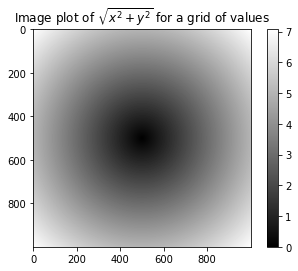

```python
import matplotlib.pyplot as plt
plt.imshow(z, cmap=plt.cm.gray); plt.colorbar()
plt.title("Image plot of $\sqrt{x^2 + y^2}$ for a grid of values")
```

```python
plt.draw()
```

```python
plt.close('all')
```

### 배열 연산으로 조건절 표현

### `np.where(조건, A, B)` : 조건이 True면 A, 아니면 B (ifelse)

```python
xarr = np.array([1.1, 1.2, 1.3, 1.4, 1.5])
yarr = np.array([2.1, 2.2, 2.3, 2.4, 2.5])
cond = np.array([True, False, True, True, False])
```

```python
np.where(cond, xarr, yarr)
```

```
array([1.1, 2.2, 1.3, 1.4, 2.5])
```

- 양수는 모두 2로, 음수는 모두 -2로

```python
arr = np.random.randn(4, 4)
np.where(arr > 0, 2, -2)
```

```
array([[ 2,  2, -2,  2],
       [ 2,  2, -2,  2],
       [ 2,  2, -2,  2],
       [ 2,  2,  2, -2]])
```

### 수학, 통계 메서드

| 메서드 | 설명 |
| --- | --- |
| sum | 합계 |
| mean | 산술평균 (0 : 각 열의 평균 / 1 : 각 행의 평균) |
| std, var | 표준편차, 분산 |
| min, max | 최소/최대값 |
| argmin, argmax | 최소/최대 원소 인덱스 |
| cumsum | 누적합 |
| cumprod | 누적곱 |

```python
arr = np.array([[0, 1, 2], [3, 4, 5], [6, 7, 8]])
arr
```

```
array([[0, 1, 2],
       [3, 4, 5],
       [6, 7, 8]])
```

```python
print(arr.mean()) # 총 평균
print(arr.mean(axis = 0)) # 각 열의 평균
print(arr.mean(axis = 1)) # 각 행의 평균
```

```
4.0
[3. 4. 5.]
[1. 4. 7.]
```

```python
print(arr.sum()) # 총 합
print(arr.cumsum(axis = 0)) # 각 열의 누적합
print(arr.cumsum(axis = 1)) # 각 행의 누적합
```

```
36
[[ 0  1  2]
 [ 3  5  7]
 [ 9 12 15]]
[[ 0  1  3]
 [ 3  7 12]
 [ 6 13 21]]
```

### boolean 배열을 위한 메서드

```python
arr = np.random.randn(100)
(arr > 0).sum() # 양수인 원소의 개수
```

```
46
```

### 정렬

```python
arr = np.random.randn(5, 3)
arr.sort(1) # 행 방향 정렬
print(arr)
arr.sort(0) # 열 방향 정렬
print(arr)
```

```
[[ 0.02404506  1.06549758  1.44579227]
 [ 0.20891907  0.92393177  1.64831018]
 [-0.77194379 -0.59179635  1.17862147]
 [-1.57753023  0.69271274  1.16140464]
 [-1.29565444 -0.64103824  0.04474225]]
[[-1.57753023 -0.64103824  0.04474225]
 [-1.29565444 -0.59179635  1.16140464]
 [-0.77194379  0.69271274  1.17862147]
 [ 0.02404506  0.92393177  1.44579227]
 [ 0.20891907  1.06549758  1.64831018]]
```

- 5% 뷘위수

```python
large_arr = np.random.randn(1000)
large_arr.sort()
large_arr[int(0.05 * len(large_arr))] # 5% 분위수
```

```
-1.6000605262129763
```

### 집합 관련 함수

| 메서드 | 설명 |
| --- | --- |
| np.unique()x | 배열 x에서 중복된 원소를 제거한 뒤 정렬하여 변환 |
| np.intersect1d(x, y) | 배열 x와 y에 공통적으로 존재하는 원소를 정렬하여 반환 |
| np.union1d(x, y) | 두 배열의 합집합을 반환 |
| np.in1d(x, y) | x의 원소가 y의 원소에 포함되는지 나타내는 boolean 배열을 반환 |
| np.setdiff1d(x, y) | x와 y의 차집합을 반환 |
| np.setxor1d(x, y) | 한 배열에는 포함되지만 두 배열 모두에는 포함되지 않는 원소들의 집합인 대칭차집합을 반환 |

```python
names = np.array(['Bob', 'Joe', 'Will', 'Bob', 'Will', 'Joe', 'Joe'])
np.unique(names)
```

```
array(['Bob', 'Joe', 'Will'], dtype='<U4')
```

```python
ints = np.array([3, 3, 3, 2, 2, 1, 1, 4, 4])
np.unique(ints)
```

```
array([1, 2, 3, 4])
```

```python
sorted(set(names))
```

```
['Bob', 'Joe', 'Will']
```

#### `np.in1d`

```python
values = np.array([6, 0, 0, 3, 2, 5, 6])
np.in1d(values, [2, 3, 6])
```

```
array([ True, False, False,  True,  True, False,  True])
```

### 배열 데이터의 파일 입출력

### `np.save('파일명', 배열)` : 배열을 npy형식으로 저장

### `np.load('파일명')` : npy파일 load

```python
import os
os.getcwd()
os.chdir('/' + os.path.join('Users', '이찬솔', 'Documents', 'Python_for_Data_Analysis', 'examples'))
os.getcwd()
```

```
'C:\\Users\\이찬솔\\Documents\\Python_for_Data_Analysis\\examples'
```

```python
arr = np.arange(10)
np.save('some_array', arr)
```

```python
np.load('some_array.npy')
```

```
array([0, 1, 2, 3, 4, 5, 6, 7, 8, 9])
```

### `np.savez('파일명.npz', a = 배열1, b = 배열2, ... )` : 여러 개의 배열을 압축된 형식으로 저장

- **저장하려는 배열을 키워드 인자 형태로 전달**

```python
np.savez('array_archive.npz', a = arr, b = arr)
arch = np.load('array_archive.npz')
```

```python
print(arch['a'])
print(arch['b'])
```

```
[0 1 2 3 4 5 6 7 8 9]
[0 1 2 3 4 5 6 7 8 9]
```

### `np.savez_compressed('파일명.npz', a = 배열1, b = 배열2, ... )`

```python
np.savez_compressed('arrays_compressed.npz', a=arr, b=arr)
```

### `np.dot(a, b)`, `@` : 행렬 곱

```python
x = np.array([[1., 2., 3.], [4., 5., 6.]])
y = np.array([[6., 23.], [-1, 7], [8, 9]])
print(x.dot(y)) # x와 y의 행렬곱
```

```
[[ 28.  64.]
 [ 67. 181.]]
```

```python
x @ np.ones(3)
```

```
array([ 6., 15.])
```

### numpy.linalg 라이브러리

- 주요 함수

| 함수 | 설명 |
| --- | --- |
| diag | 정사각 행렬의 대각/비대각 원소를 1차원 배열로 반환하거나, 1차원 배열을 대각선 원소로 하고 나머지는 0으로 채운 단위행렬을 반환 |
| dot | 행렬 곱셈 |
| trace | 행렬의 대각선 원소의 합 |
| det | 행렬식 |
| eig | 정사각 행렬의 고윳값과 고유벡터 |
| inv | 정사각 행렬의 역행렬 |
| pinv | 정사각 행렬의 무어-펜로즈 유사역원 역행렬 |
| qr | QR 분해 |
| svd | 특잇값 분해(SVD) |
| solve | A가 정사각 행렬일 때 Ax = b를 만족하는 x를 구한다 |
| lstsq | Ax = b를 만족하는 최소제곱해 |

```python
from numpy.linalg import inv, qr
```

```python
X = np.random.randn(5, 5)
```

```python
mat = X.T.dot(X) # X의 전치행렬과 X의 곱
```

#### `inv()` : 역행렬

```python
inv(mat)
```

```
array([[ 9.77648502, -0.56621058,  3.0115257 ,  6.79700387, -2.67861044],
       [-0.56621058,  0.31916689, -0.65526685, -0.58979766,  0.61070825],
       [ 3.0115257 , -0.65526685,  2.67316112,  2.54525062, -2.10728685],
       [ 6.79700387, -0.58979766,  2.54525062,  5.12112183, -2.31311486],
       [-2.67861044,  0.61070825, -2.10728685, -2.31311486,  1.9055965 ]])
```

```python
np.rint(mat.dot(inv(mat)))
```

```
array([[ 1.,  0.,  0., -0.,  0.],
       [ 0.,  1.,  0.,  0.,  0.],
       [-0.,  0.,  1., -0.,  0.],
       [ 0.,  0., -0.,  1., -0.],
       [ 0., -0., -0., -0.,  1.]])
```

#### `qr()` : QR분해, 실수 행렬을 직교 행렬과 상삼각 행렬의 곱으로 나타내는 행렬 분해

- 직교행렬 : 역행렬과 전치행렬이 동일한 n X n 행렬

```python
q, r = qr(mat)
print(q)
print(r)
```

```
[[-0.51791971 -0.04364125 -0.15271154 -0.60364447 -0.58493346]
 [ 0.2575428  -0.88429179 -0.29930731 -0.21054588  0.13336157]
 [ 0.088325    0.0627121  -0.69521103  0.54146919 -0.46017239]
 [ 0.77741154  0.12514801  0.24984544 -0.24980165 -0.50511946]
 [ 0.23078318  0.44331551 -0.5842544  -0.48548331  0.41612887]]
[[-3.60524319  2.62133675  1.58344298  5.81976419  3.02866886]
 [ 0.         -9.83330148  2.22367705  0.94294372  6.98765786]
 [ 0.          0.         -3.92051107 -0.22006817 -4.90919184]
 [ 0.          0.          0.         -0.36272552 -0.69506272]
 [ 0.          0.          0.          0.          0.21837198]]
```

### 난수생성

- `np.random`

| 함수 | 설명 |
| --- | --- |
| seed | 난수 생성기 시드 |
| permutation | 순서를 임의로 바꾸거나 임의의 순열을 반환 |
| shuffle | 리스트나 배열의 순서를 뒤섞음 |
| rand | 균등분포에서 표본 추출 |
| randint(low, high, size) | 주어진 최소/최대 범위 안에서 임의의 난수를 추출 |
| randn | 표준정규분포에서 표본 추출 |
| binomial(n, p, size) | 이항분포에서 표본 추출 |
| normal(loc, scale, size) | 정규분포에서 표본 추출 |
| beta | 베타분포에서 표본 추출 |
| chisquare(df, size) | 카이제곱분포에서 표본 추출 |
| gamma | 감마분포에서 표본 추출 |
| uniform(low, high, size) | 균등분포[0, 1] 에서 표본 추출 |
| hypergeometric(ngood, nbad, nsample, size) | 초기하분포에서 표본 추출 |
| poisson(lam, size) | 포아송분포에서 표본 추출 |
| standard_t(df, size) | t-분포에서 표본 추출 |
| f(dfnum, dfden, size) | F-분포에서 표본 추출 |

#### `np.random.normal(size)` : 정규분포에서 size만큼의 난수 생성

- 파이썬 내장 random 모듈보다 훨씬 빠른 속도

```python
from random import normalvariate
N = 1000000

%timeit samples = [normalvariate(0, 1) for _ in range(N)]
```

```
1.58 s ± 111 ms per loop (mean ± std. dev. of 7 runs, 1 loop each)
```

```python
%timeit np.random.normal(size = N)
```

```
52.2 ms ± 3.41 ms per loop (mean ± std. dev. of 7 runs, 10 loops each)
```

#### `np.random.seed(seed)` : 시드값 설정

```python
np.random.seed(1234)
```

#### `np.random.RandomState(seed)` : 다른 난수 생성기로부터 격리된 난수 생성기를 생성

```python
rng = np.random.RandomState(1234)
```

```python
rng.randn(10)
```

```
array([ 0.47143516, -1.19097569,  1.43270697, -0.3126519 , -0.72058873,
        0.88716294,  0.85958841, -0.6365235 ,  0.01569637, -2.24268495])
```

### 계단 오르내리기 예제

```python
import random
```

```python
np.random.seed(12345)
position = 0
walk = [position]
steps = 1000
for i in range(steps):
    step = 1 if random.randint(0, 1) else -1
    position += step
    walk.append(position)
```

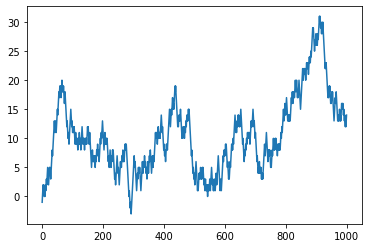

```python
plt.figure()
plt.plot(walk[:1000])
plt.show()
```

- 계단을 오르내린 위치의 최소/최댓값

```python
nsteps = 1000
draws = np.random.randint(0, 2, size = nsteps)
steps = np.where(draws > 0, 1, -1)
walk = steps.cumsum()
```

```python
print(walk.min())
print(walk.max())
```

```
-3
31
```

- 계단에서 특정 위치에 도달하기까지의 시간
- 처음 위치에서 10칸 이상 떨어진 시점

```python
(np.abs(walk) >= 10).argmax()
```

```
37
```

### 시뮬레이션

- 1000번의 계단 오르내림을 5000번 시행

```python
nwalks = 5000
nsteps = 1000

draws = np.random.randint(0, 2, size = (nwalks, nsteps)) # 0 or 1
steps = np.where(draws > 0, 1, -1)
walks = steps.cumsum(1) # 각 시행의 최종값 (누적합)
walks.shape
```

```
(5000, 1000)
```

- 시뮬레이션의 최대/최솟값

```python
print(walks.max()) # 가장 멀리간 시행결과
print(walks.min()) # 가장 멀리가지 못한 시행결과
```

```
112
-117
```

- 데이터에서 누적합이 30 혹은 -30이 되는 최소 시점
- `.any()` : 하나라도 True인게 있으면 True
- `.all()` : 모두 True여야 True 반환

```python
hits30 = (np.abs(walks) >= 30).any(1)
# 행 방향 으로 .any 적용 => 최종값의 절댓값이 30이상인지의 여부
hits30.shape
```

```
(5000,)
```

```python
hits30.sum() # 누적합이 30 또는 -30이 되는 시행의 수
```

```
3390
```

- 절댓값이 30을 넘는 경우에 대해 행 방향으로 argmax값을 계산 => 처음 위치에서 30칸 이상 멀어지는 최소 횟수

```python
crossing_times = (np.abs(walks[hits30]) >= 30).argmax(1)
# 최종값의 절댓값이 30이상인 시행
crossing_times.mean()
```

```
503.0064896755162
```

```python
steps = np.random.normal(loc = 0, scale = 0.25,
                         size=(nwalks, nsteps))
```